# Project Foundations for Data Science: FoodHub Data Analysis

**Marks: 60**

### Context

The number of restaurants in New York is increasing day by day. Lots of students and busy professionals rely on those restaurants due to their hectic lifestyles. Online food delivery service is a great option for them. It provides them with good food from their favorite restaurants. A food aggregator company FoodHub offers access to multiple restaurants through a single smartphone app.

The app allows the restaurants to receive a direct online order from a customer. The app assigns a delivery person from the company to pick up the order after it is confirmed by the restaurant. The delivery person then uses the map to reach the restaurant and waits for the food package. Once the food package is handed over to the delivery person, he/she confirms the pick-up in the app and travels to the customer's location to deliver the food. The delivery person confirms the drop-off in the app after delivering the food package to the customer. The customer can rate the order in the app. The food aggregator earns money by collecting a fixed margin of the delivery order from the restaurants.

### Objective

The food aggregator company has stored the data of the different orders made by the registered customers in their online portal. They want to analyze the data to get a fair idea about the demand of different restaurants which will help them in enhancing their customer experience. Suppose you are hired as a Data Scientist in this company and the Data Science team has shared some of the key questions that need to be answered. Perform the data analysis to find answers to these questions that will help the company to improve the business.

### Data Description

The data contains the different data related to a food order. The detailed data dictionary is given below.

### Data Dictionary

- order_id: Unique ID of the order
- customer_id: ID of the customer who ordered the food
- restaurant_name: Name of the restaurant
- cuisine_type: Cuisine ordered by the customer
- cost: Cost of the order
- day_of_the_week: Indicates whether the order is placed on a weekday or weekend (The weekday is from Monday to Friday and the weekend is Saturday and Sunday)
- rating: Rating given by the customer out of 5
- food_preparation_time: Time (in minutes) taken by the restaurant to prepare the food. This is calculated by taking the difference between the timestamps of the restaurant's order confirmation and the delivery person's pick-up confirmation.
- delivery_time: Time (in minutes) taken by the delivery person to deliver the food package. This is calculated by taking the difference between the timestamps of the delivery person's pick-up confirmation and drop-off information

### Let us start by importing the required libraries

```python
# import libraries for data manipulation
import numpy as np
import pandas as pd

# import libraries for data visualization
import matplotlib.pyplot as plt
import seaborn as sns
```

### Understanding the structure of the data

```python
# read the data
df = pd.read_csv('foodhub_order.csv')
# returns the first 5 rows
df.head()
```

|  | order_id | customer_id | restaurant_name | cuisine_type | cost_of_the_order | day_of_the_week | rating | food_preparation_time | delivery_time |
| --- | --- | --- | --- | --- | --- | --- | --- | --- | --- |
| 0 | 1477147 | 337525 | Hangawi | Korean | 30.75 | Weekend | Not given | 25 | 20 |
| 1 | 1477685 | 358141 | Blue Ribbon Sushi Izakaya | Japanese | 12.08 | Weekend | Not given | 25 | 23 |
| 2 | 1477070 | 66393 | Cafe Habana | Mexican | 12.23 | Weekday | 5 | 23 | 28 |
| 3 | 1477334 | 106968 | Blue Ribbon Fried Chicken | American | 29.20 | Weekend | 3 | 25 | 15 |
| 4 | 1478249 | 76942 | Dirty Bird to Go | American | 11.59 | Weekday | 4 | 25 | 24 |

#### Observations:

The DataFrame has 9 columns as mentioned in the Data Dictionary. Data in each row corresponds to the order placed by a customer.

### **Question 1:** How many rows and columns are present in the data? [0.5 mark]

```python
# Write your code here
# Number of rows in the dataset
num_rows = df.shape[0]
# Number of columns in the dataset
num_columns = df.shape[1]

# Print the number of rows and columns in the data
print("The data has " + str(num_rows) + " rows and " + str(num_columns) + " columns.")
```

```
The data has 1898 rows and 9 columns.
```

[output not shown]

#### Observations:

The data frame has 1898 rows and 9 columns.

### **Question 2:** What are the datatypes of the different columns in the dataset? (The info() function can be used) [0.5 mark]

```python
# Use info() to obtain a concise summary of the DataFrame
df.info()
```

```
<class 'pandas.core.frame.DataFrame'>
RangeIndex: 1898 entries, 0 to 1897
Data columns (total 9 columns):
 #   Column                 Non-Null Count  Dtype
---  ------                 --------------  -----
 0   order_id               1898 non-null   int64
 1   customer_id            1898 non-null   int64
 2   restaurant_name        1898 non-null   object
 3   cuisine_type           1898 non-null   object
 4   cost_of_the_order      1898 non-null   float64
 5   day_of_the_week        1898 non-null   object
 6   rating                 1898 non-null   object
 7   food_preparation_time  1898 non-null   int64
 8   delivery_time          1898 non-null   int64
dtypes: float64(1), int64(4), object(4)
memory usage: 133.6+ KB
```

#### Observations:

The data frame column datatypes:

1. order_id : int64
2. customer_id : int64
3. restaurant_name : object
4. cuisine_type : object
5. cost_of_the_order : float64
6. day_of_the_week : object
7. rating : object
8. food_preparation_time : int64
9. delivery_time : int64

### **Question 3:** Are there any missing values in the data? If yes, treat them using an appropriate method. [1 mark]

```python
# Write your code here
# From using info() in Questiion 2, it can be seen there are no missing values.
```

#### Observations:

From using info() in Questiion 2, it can be seen there are no missing values via the non-null count column. However, if there were any missing values in the dataframe, that data point would be removed as well as its assosciated data. Alternatively, other appropriate methods include filling the missing value with the mean or median, interpolation, K-nearest neighbour or machine learning solutions.

### **Question 4:** Check the statistical summary of the data. What is the minimum, average, and maximum time it takes for food to be prepared once an order is placed? [2 marks]

```python
# Write your code here
# Use describe() to obtain a concise statistical summary of the DataFrame
stat_summary = df.describe()

# Print statistical summary
print(stat_summary)
```

```
           order_id    customer_id  cost_of_the_order  food_preparation_time  \
count  1.898000e+03    1898.000000        1898.000000            1898.000000
mean   1.477496e+06  171168.478398          16.498851              27.371970
std    5.480497e+02  113698.139743           7.483812               4.632481
min    1.476547e+06    1311.000000           4.470000              20.000000
25%    1.477021e+06   77787.750000          12.080000              23.000000
50%    1.477496e+06  128600.000000          14.140000              27.000000
75%    1.477970e+06  270525.000000          22.297500              31.000000
max    1.478444e+06  405334.000000          35.410000              35.000000

       delivery_time
count    1898.000000
mean       24.161749
std         4.972637
min        15.000000
25%        20.000000
50%        25.000000
75%        28.000000
max        33.000000
```

#### Observations:

Statisitcal summary of Food Preparation Times:

- Mean (Average): 27.37 minutes
- Minimum: 20.00 minutes
- Maximum: 35.00 minutes

### **Question 5:** How many orders are not rated? [1 mark]

```python
# Write the code here
# Use value_count() to obtain the number of each different value in the data frame.
df.value_counts('rating')
```

| rating | count |
| --- | --- |
| Not given | 736 |
| 5 | 588 |
| 4 | 386 |
| 3 | 188 |

**dtype:** int64

#### Observations:

Within the dataframe there were 736 orders which were not rated.

### Exploratory Data Analysis (EDA)

### **Question 6:** Explore all the variables and provide observations on their distributions. (Generally, histograms, boxplots, countplots, etc. are used for univariate exploration.) [9 marks]

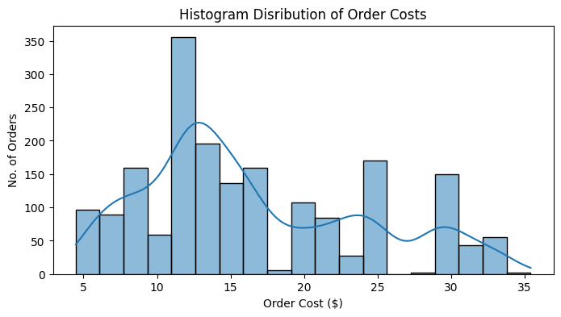

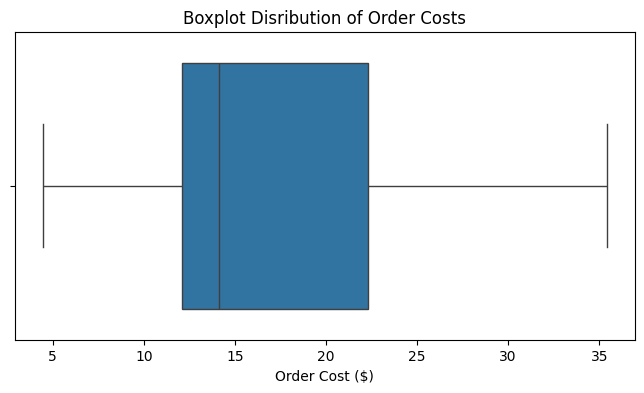

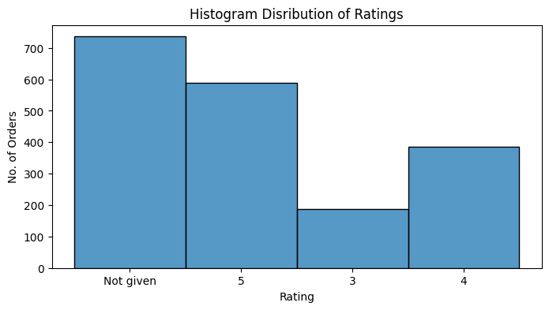

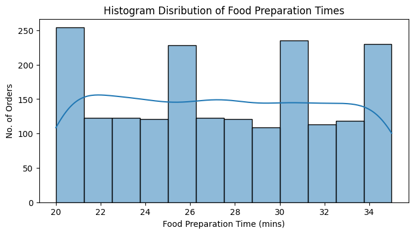

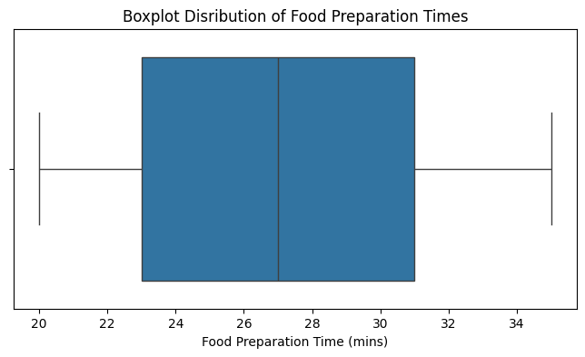

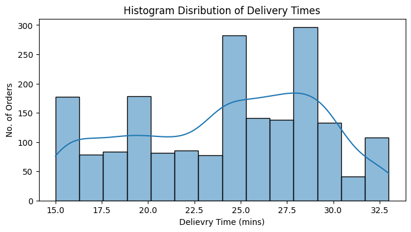

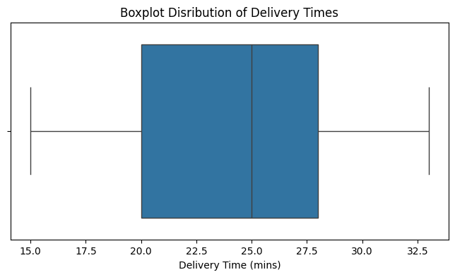

```python
# Write the code here
## Visualising the Distributions
### Numerical Data

# Order Costs
# Histogram
plt.figure(figsize=(8, 4))
sns.histplot(df['cost_of_the_order'], kde=True)
plt.title(f'Histogram Disribution of Order Costs')
plt.xlabel(f'Order Cost ($)')
plt.ylabel(f'No. of Orders')
plt.show()

# Boxplot
plt.figure(figsize=(8, 4))
sns.boxplot(x=df['cost_of_the_order'])
plt.title(f'Boxplot Disribution of Order Costs')
plt.xlabel(f'Order Cost ($)')
plt.show()

# Rating
# Histogram
plt.figure(figsize=(8, 4))
sns.histplot(df['rating'])
plt.title(f'Histogram Disribution of Ratings')
plt.xlabel(f'Rating')
plt.ylabel(f'No. of Orders')
plt.show()

# Food Preparation Time
# Histogram
plt.figure(figsize=(8, 4))
sns.histplot(df['food_preparation_time'], kde=True)
plt.title(f'Histogram Disribution of Food Preparation Times')
plt.xlabel(f'Food Preparation Time (mins)')
plt.ylabel(f'No. of Orders')
plt.show()

# Boxplot
plt.figure(figsize=(8, 4))
sns.boxplot(x=df['food_preparation_time'])
plt.title(f'Boxplot Disribution of Food Preparation Times')
plt.xlabel(f'Food Preparation Time (mins)')
plt.show()

# Delivery Time
# Histogram
plt.figure(figsize=(8, 4))
sns.histplot(df['delivery_time'], kde=True)
plt.title(f'Histogram Disribution of Delivery Times')
plt.xlabel(f'Delievry Time (mins)')
plt.ylabel(f'No. of Orders')
plt.show()

# Boxplot
plt.figure(figsize=(8, 4))
sns.boxplot(x=df['delivery_time'])
plt.title(f'Boxplot Disribution of Delivery Times')
plt.xlabel(f'Delivery Time (mins)')
plt.show()
```

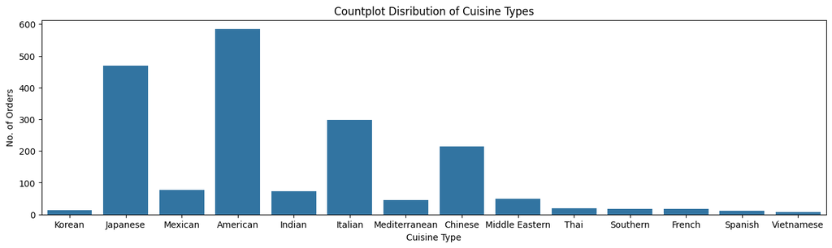

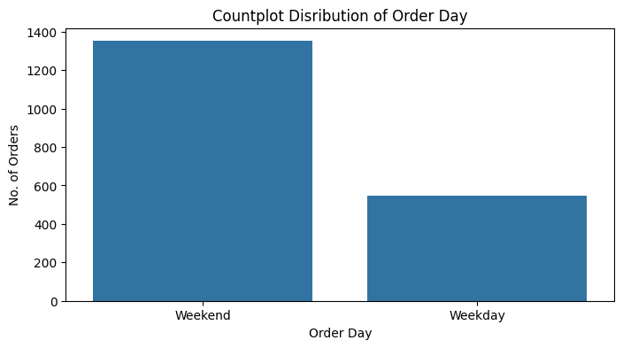

```python
### Categorical Data (Countplots)

# Cuisie Type
plt.figure(figsize=(16, 4))
sns.countplot(x=df['cuisine_type'])
plt.title(f'Countplot Disribution of Cuisine Types')
plt.xlabel(f'Cuisine Type')
plt.ylabel(f'No. of Orders')
plt.show()

# Order Day
plt.figure(figsize=(8, 4))
sns.countplot(x=df['day_of_the_week'])
plt.title(f'Countplot Disribution of Order Day')
plt.xlabel(f'Order Day')
plt.ylabel(f'No. of Orders')
plt.show()
```

### **Question 7**: Which are the top 5 restaurants in terms of the number of orders received? [1 mark]

```python
# Write the code here
# Group by restaurant name and count the number of orders
restaurant_order_counts = df.groupby('restaurant_name').size().reset_index(name='num_orders')

# Sort the restaurants by the number of orders in descending order
top_5_restaurants = restaurant_order_counts.sort_values(by='num_orders', ascending=False).head(5)

# Display the top 5 restaurants
print(top_5_restaurants)
```

```
               restaurant_name  num_orders
136                Shake Shack         219
153          The Meatball Shop         132
21           Blue Ribbon Sushi         119
20   Blue Ribbon Fried Chicken          96
109                       Parm          68
```

#### Observations:

The top 5 restaurants in terms of the number of orders received are:

1. Shake Shack
2. The Meatball Shop
3. Blue Ribbon Sushi
4. Blue Ribbon Fried Chicken
5. Parm

### **Question 8**: Which is the most popular cuisine on weekends? [1 mark]

```python
# Write the code here
# Filter dataset for just weekend orders
weekend_orders = df[df['day_of_the_week'].isin(['Weekend'])]

# Group by Cuisine Type and count the number of orders for each cuisine
cuisine_popularity = weekend_orders.groupby('cuisine_type').size().reset_index(name='num_orders')

# Sort the results in descending order to find the most popular cuisine
most_popular_cuisine = cuisine_popularity.sort_values(by='num_orders', ascending=False).head(1)

# Display the most popular cuisine on weekends
print(most_popular_cuisine)
```

```
  cuisine_type  num_orders
0     American         415
```

#### Observations:

The most popular cuisine on weekends is American cuisine.

### **Question 9**: What percentage of the orders cost more than 20 dollars? [2 marks]

```python
# Write the code here
# Total number of orders
total_orders = df.shape[0]

# Number of orders with cost greater than 20
orders_above_20 = df[df['cost_of_the_order'] > 20].shape[0]

# Calculate the percentage
percentage_above_20 = (orders_above_20 / total_orders) * 100

# Display the result
print(f"Percentage of orders costing more than $20: {percentage_above_20:.2f}%")
```

```
Percentage of orders costing more than $20: 29.24%
```

#### Observations:

The percentage of orders which cost more than 20$ is 29.24%.

### **Question 10**: What is the mean order delivery time? [1 mark]

```python
# Write the code here
# Can be found above in Question 4 from using describe().
```

#### Observations:

The mean order delivery time is 24.16 mins.

### **Question 11:** The company has decided to give 20% discount vouchers to the top 3 most frequent customers. Find the IDs of these customers and the number of orders they placed. [1 mark]

```python
# Write the code here
# Group by customer id and count the number of orders
customer_order_counts = df.groupby('customer_id').size().reset_index(name='num_orders')

# Sort the restaurants by the number of orders in descending order
top_5_customers = customer_order_counts.sort_values(by='num_orders', ascending=False).head(5)

# Display the top 5 restaurants
print(top_5_customers)
```

```
     customer_id  num_orders
116        52832          13
84         47440          10
333        83287           9
839       250494           8
216        65009           7
```

#### Observations:

The 3 most frequent customers and the number of orders they placed:

- 52832 : 13 Orders
- 47440 : 10 Orders
- 83287 : 9 Orders